# Reproducible Research: Peer Assessment 1

### Loading and preprocessing the data

```r
library(ggplot2)
library(lattice)
rm(list=ls())
setwd("~/R/Coursera/5-Reproducible Research/Week2-CourseProject/RepData_PeerAssessment1-master")
unzip("activity.zip")
activity<-read.csv("activity.csv", header=TRUE, sep=",")
```

### What is mean total number of steps taken per day?

#### Make a histogram of the total number of steps taken each day

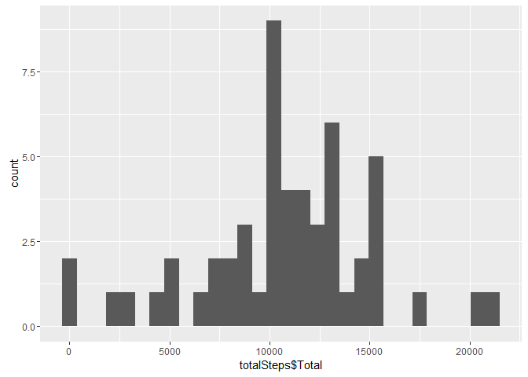

```r
activitySubset<-subset(activity, subset=(steps>0))
totalSteps<-aggregate(activitySubset$steps, by=list(Category=activitySubset$date), FUN=sum)
colnames(totalSteps)<-c("Date", "Total")
qplot(totalSteps$Total)
```

#### Calculate and report the mean and median total number of steps taken per day

```r
options(scipen=999)
meanSteps<-mean(totalSteps$Total)
medianSteps<-median(totalSteps$Total)
```

The mean number of steps is 10766.1886792. The median number is 10765.

### What is the average daily activity pattern?

#### Make a time series plot (i.e. type = “l”) of the 5-minute interval (x-axis) and the average number of steps taken, averaged across all days (y-axis)

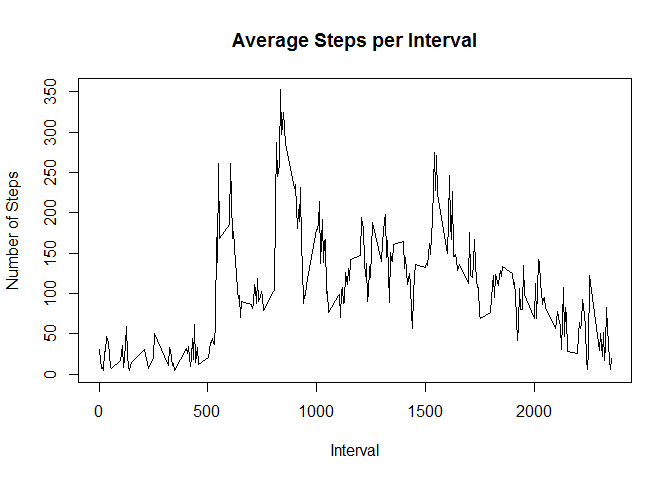

```r
averageSteps<-aggregate(activitySubset$steps, by=list(activitySubset$interval), FUN=mean)
colnames(averageSteps)<-c("interval","average")
plot(averageSteps, type="l", main="Average Steps per Interval", xlab="Interval", ylab="Number of Steps")
```

#### Which 5-minute interval, on average across all the days in the dataset, contains the maximum number of steps?

```r
averageSteps<-averageSteps[order(-averageSteps$average),]
maxAverageSteps<-averageSteps[1,1]
```

The maximum number of steps occurs, on average, at the 835 interval.

### Imputing missing values

#### Calculate and report the total number of missing values in the dataset (i.e. the total number of rows with NAs)

```r
activityNA<-subset(activity, is.na(activity$steps)==TRUE)
colSums(is.na(activity))
```

```
##    steps     date interval
##     2304        0        0
```

There are 2304 missing values in the dataset.

### Devise a strategy for filling in all of the missing values in the dataset. The strategy does not need to be sophisticated. For example, you could use the mean/median for that day, or the mean for that 5-minute interval, etc.

#### Create a new dataset that is equal to the original dataset but with the missing data filled in.

```r
averageSteps<-averageSteps[order(averageSteps$interval),]
activity$complete<-ifelse(is.na(activity$steps), averageSteps[match(activity$interval, averageSteps$interval),2] ,activity$steps)
activity$complete<-ifelse(is.na(activity$complete), mean(activitySubset$steps) ,activity$complete)
```

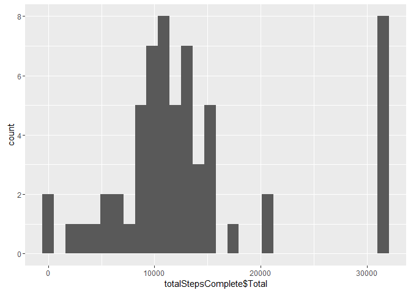

```r
totalStepsComplete<-aggregate(activity$complete, by=list(Category=activity$date), FUN=sum)
colnames(totalStepsComplete)<-c("Date", "Total")
qplot(totalStepsComplete$Total)
```

```r
meanStepsComplete<-mean(totalStepsComplete$Total)
medianStepsComplete<-median(totalStepsComplete$Total)
```

### Are there differences in activity patterns between weekdays and weekends?

#### Create a new factor variable in the dataset with two levels - “weekday” and “weekend” indicating whether a given date is a weekday or weekend day.

```r
activity$day<-weekdays(as.Date(activity$date))
weekend<-c("Sunday", "Saturday")
activity$WEWD<-c("weekday", "weekend")[(activity$day %in% weekend)+1L]
```

#### Make a panel plot containing a time series plot (i.e. type = “l”) of the 5-minute interval (x-axis) and the average number of steps taken, averaged across all weekday days or weekend days (y-axis). The plot should look something like the following, which was creating using simulated data.

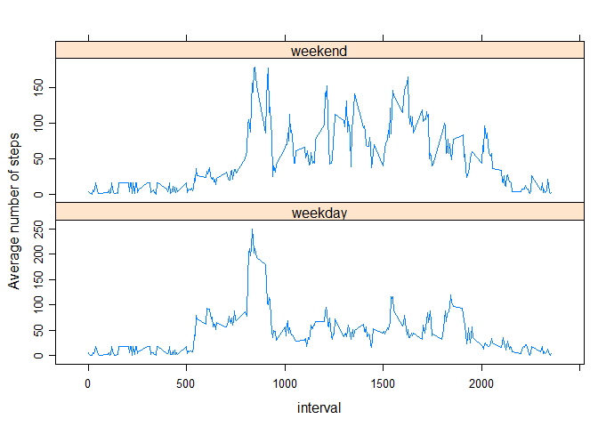

```r
averageStepsComplete<-aggregate(activity$complete, by=list(activity$interval, activity$WEWD), FUN=mean)
colnames(averageStepsComplete)<-c("interval","WEWD", "steps")
xyplot(steps~interval|WEWD, data=averageStepsComplete, type="l", scales=list(y=list(relation="free")),layout=c(1,2), ylab="Average number of steps")
```

1. Weekends tend to have a greater number of steps over a longer period of time.
2. Weekdays have a spike in the morning that is greater than any of the weekend values. Maybe that’s when people are out for a morning run?
3. Weekend activity tapers off later than weekday activity.